# Elsevier 2022 SDG mapping

)

)

)

)

OR

(

(

(

(

(TITLE("rural* communit*") OR TITLE("low* socioeconomic* population*") OR TITLE("lowest socioeconomic status") OR TITLE("ghetto*") OR TITLE("vulnerable* communit*") OR TITLE("poverty") OR TITLE("poor people") OR TITLE("poorer people") OR TITLE("poor* village*") OR TITLE("developing* countr*") OR TITLE("least* developed* countr*")) AND TITLE("emergency savings")

)

OR

(

(AUTHKEY("rural* communit*") OR AUTHKEY("low* socioeconomic* population*") OR AUTHKEY("lowest socioeconomic status") OR AUTHKEY("ghetto*") OR AUTHKEY("vulnerable* communit*") OR AUTHKEY("poverty") OR AUTHKEY("poor people") OR AUTHKEY("poorer people") OR AUTHKEY("poor* village*") OR AUTHKEY("developing* countr*") OR AUTHKEY("least* developed* countr*")) AND AUTHKEY("emergency savings")

)

OR

(

(TITLE("rural* communit*") OR TITLE("low* socioeconomic* population*") OR TITLE("lowest socioeconomic status") OR TITLE("ghetto*")) AND (TITLE("disaster*") OR TITLE("resilien*") OR TITLE("extreme* weather*") OR TITLE("extreme* rainfall*") OR TITLE("typhoon*") OR TITLE("hurricane*") OR TITLE("earthquake*") OR TITLE("flood") OR TITLE("floods") OR TITLE("drought*") OR TITLE("crisis") OR TITLE("preparedness") OR TITLE("tsunami*") OR TITLE("wildfire*") OR TITLE("vulnerabilit*") OR TITLE("natural* hazard*"))

)

OR

(

(AUTHKEY("rural* communit*") OR AUTHKEY("low* socioeconomic* population*") OR AUTHKEY("lowest socioeconomic status") OR AUTHKEY("ghetto*")) AND (AUTHKEY("disaster*") OR AUTHKEY("resilien*") OR AUTHKEY("extreme* weather*") OR AUTHKEY("extreme* rainfall*") OR AUTHKEY("typhoon*") OR AUTHKEY("hurricane*") OR AUTHKEY("earthquake*") OR AUTHKEY("flood") OR AUTHKEY("floods") OR AUTHKEY("drought*") OR AUTHKEY("crisis") OR AUTHKEY("preparedness") OR AUTHKEY("tsunami*") OR AUTHKEY("wildfire*") OR AUTHKEY("vulnerabilit*") OR AUTHKEY("natural* hazard*"))

)

OR

(

TITLE("least* developed* countr*") AND (TITLE("disaster*") OR TITLE("resilien*") OR TITLE("extreme* weather*") OR TITLE("extreme* rainfall*") OR TITLE("typhoon*") OR TITLE("hurricane*") OR TITLE("earthquake*") OR TITLE("flood") OR TITLE("floods") OR TITLE("drought*") OR TITLE("crisis") OR TITLE("preparedness") OR TITLE("tsunami*") OR TITLE("wildfire*") OR TITLE("vulnerabilit*") OR TITLE("natural* hazard*"))

)

OR

(

AUTHKEY("least* developed* countr*") AND (AUTHKEY("disaster*") OR AUTHKEY("resilien*") OR AUTHKEY("extreme* weather*") OR AUTHKEY("extreme* rainfall*") OR AUTHKEY("typhoon*") OR AUTHKEY("hurricane*") OR AUTHKEY("earthquake*") OR AUTHKEY("flood") OR AUTHKEY("floods") OR AUTHKEY("drought*") OR AUTHKEY("crisis") OR AUTHKEY("preparedness") OR AUTHKEY("tsunami*") OR AUTHKEY("wildfire*") OR AUTHKEY("vulnerabilit*") OR AUTHKEY("natural* hazard*"))

)

OR

(

TITLE("poverty") AND (TITLE("resiliency") OR TITLE("resilience") OR TITLE("natural* disaster*") OR TITLE("financial crisis") OR TITLE("economic crisis") OR TITLE("economic* disaster*") OR TITLE("financial* disaster*") OR TITLE("industrial disaster"))

)

OR

(

AUTHKEY("poverty") AND (AUTHKEY("resiliency") OR AUTHKEY("resilience") OR AUTHKEY("natural* disaster*") OR AUTHKEY("financial crisis") OR AUTHKEY("economic crisis") OR AUTHKEY("economic* disaster*") OR AUTHKEY("financial* disaster*") OR AUTHKEY("industrial disaster"))

)

OR

(

(TITLE("vulnerable* communit*") OR TITLE("poverty") OR TITLE("poor people") OR TITLE("poorer people") OR TITLE("poor* village*") OR TITLE("developing* countr*")) AND (TITLE("natural* hazard*") OR TITLE("disaster*") OR TITLE("crisis")) AND (TITLE("recovery") OR TITLE("preparedness") OR TITLE("reconstruction"))

)

OR

(

(AUTHKEY("vulnerable* communit*") OR AUTHKEY("poverty") OR AUTHKEY("poor people") OR AUTHKEY("poorer people") OR AUTHKEY("poor* village*") OR AUTHKEY("developing* countr*")) AND (AUTHKEY("natural* hazard*") OR AUTHKEY("disaster*") OR AUTHKEY("crisis")) AND (AUTHKEY("recovery") OR AUTHKEY("preparedness") OR AUTHKEY("reconstruction"))

)

OR

(

(TITLE("rural* communit*") OR TITLE("low* socioeconomic* population*") OR TITLE("lowest socioeconomic status") OR TITLE("ghetto*") OR TITLE("vulnerable* communit*") OR TITLE("poverty") OR TITLE("poor people") OR TITLE("poorer people") OR TITLE("poor* village*") OR TITLE("developing* countr*") OR TITLE("least* developed* countr*")) AND (TITLE("adaptative* capacit*") OR TITLE("adaptation*") OR TITLE("landslide*") OR TITLE("crises"))

)

OR

(

(AUTHKEY("rural* communit*") OR AUTHKEY("low* socioeconomic* population*") OR AUTHKEY("lowest socioeconomic status") OR AUTHKEY("ghetto*") OR AUTHKEY("vulnerable* communit*") OR AUTHKEY("poverty") OR AUTHKEY("poor people") OR AUTHKEY("poorer people") OR AUTHKEY("poor* village*") OR AUTHKEY("developing* countr*") OR AUTHKEY("least* developed* countr*")) AND (AUTHKEY("adaptative* capacit*") OR AUTHKEY("adaptation*") OR AUTHKEY("landslide*") OR AUTHKEY("crises"))

)

OR

(

(TITLE-ABS("vulnerable* communit*") OR TITLE-ABS("poverty") OR TITLE-ABS("poor people") OR TITLE-ABS("poorer people") OR TITLE-ABS("poor village") OR TITLE-ABS("developing* countr*")) AND TITLE-ABS("sendai* framework*")

)

OR

(

(AUTHKEY("vulnerable* communit*") OR AUTHKEY("poverty") OR AUTHKEY("poor people") OR AUTHKEY("poorer people") OR AUTHKEY("poor village") OR AUTHKEY("developing* countr*")) AND AUTHKEY("sendai* framework*")

)

OR

(

(TITLE-ABS("vulnerable* communit*") OR TITLE-ABS("poverty") OR TITLE-ABS("poor people") OR TITLE-ABS("poorer people") OR TITLE-ABS("poor village") OR TITLE-ABS("developing* countr*")) AND (TITLE-ABS("tsunami*") OR TITLE-ABS("wildfire"))

)

OR

(

(AUTHKEY("vulnerable* communit*") OR AUTHKEY("poverty") OR AUTHKEY("poor people") OR AUTHKEY("poorer people") OR AUTHKEY("poor village") OR AUTHKEY("developing* countr*")) AND (AUTHKEY("tsunami*") OR AUTHKEY("wildfire"))

)

OR

(

(TITLE-ABS("vulnerable* communit*") OR TITLE-ABS("poverty") OR TITLE-ABS("poor people") OR TITLE-ABS("poorer people") OR TITLE-ABS("poor village") OR TITLE-ABS("developing* countr*")) AND (TITLE-ABS("resilien*") OR TITLE-ABS("preparedness to crisis") OR TITLE-ABS("financial crisis") OR TITLE-ABS("economic crisis"))

)

OR

(

(AUTHKEY("vulnerable* communit*") OR AUTHKEY("poverty") OR AUTHKEY("poor people") OR AUTHKEY("poorer people") OR AUTHKEY("poor village") OR AUTHKEY("developing* countr*")) AND (AUTHKEY("resilien*") OR AUTHKEY("preparedness to crisis") OR AUTHKEY("financial crisis") OR AUTHKEY("economic crisis"))

)

OR TITLE-ABS

(

"resilience of the poor"

)

OR AUTHKEY

(

"resilience of the poor"

)

OR

(

(TITLE-ABS("vulnerable* communit*") OR TITLE-ABS("poverty") OR TITLE-ABS("poor people") OR TITLE-ABS("poorer people") OR TITLE-ABS("poor village") OR TITLE-ABS("developing* countr*")) AND (TITLE-ABS("resilien*") OR TITLE-ABS("preparedness to crisis"))

)

OR

(

(AUTHKEY("vulnerable* communit*") OR AUTHKEY("poverty") OR AUTHKEY("poor people") OR AUTHKEY("poorer people") OR AUTHKEY("poor village") OR AUTHKEY("developing* countr*")) AND (AUTHKEY("resilien*") OR AUTHKEY("preparedness to crisis"))

)

OR TITLE-ABS

(

"community vulnerability assessment"

)

OR AUTHKEY

(

"community vulnerability assessment"

)

OR

(

(TITLE-ABS("Social vulnerability assessment") OR TITLE-ABS("assessing social vulnerability")) AND (TITLE-ABS("disasters*") OR TITLE-ABS("hazards") OR TITLE-ABS("extreme* weather*") OR TITLE-ABS("extreme* rainfall*") OR TITLE-ABS("typhoon*") OR TITLE-ABS("hurricane*") OR TITLE-ABS("earthquake*") OR TITLE-ABS("flood") OR TITLE-ABS("floods") OR TITLE-ABS("drought*"))

)

OR

(

(AUTHKEY("Social vulnerability assessment") OR AUTHKEY("assessing social vulnerability")) AND (AUTHKEY("disasters*") OR AUTHKEY("hazards") OR AUTHKEY("extreme* weather*") OR AUTHKEY("extreme* rainfall*") OR AUTHKEY("typhoon*") OR AUTHKEY("hurricane*") OR AUTHKEY("earthquake*") OR AUTHKEY("flood") OR AUTHKEY("floods") OR AUTHKEY("drought*"))

)

OR

(

(TITLE-ABS("vulnerable* communit*") OR TITLE-ABS("poverty") OR TITLE-ABS("poor people") OR TITLE-ABS("poorer people") OR TITLE-ABS("poor village") OR TITLE-ABS("developing* countr*")) AND TITLE-ABS("vulnerability assessment")

)

OR

(

(AUTHKEY("vulnerable* communit*") OR AUTHKEY("poverty") OR AUTHKEY("poor people") OR AUTHKEY("poorer people") OR AUTHKEY("poor village") OR AUTHKEY("developing* countr*")) AND AUTHKEY("vulnerability assessment")

)

OR

(

TITLE-ABS("Social vulnerability index") OR TITLE-ABS("SSVI")

)

OR

(

AUTHKEY("Social vulnerability index") OR AUTHKEY("SSVI")

)

OR

(

(TITLE-ABS("vulnerable* communit*") OR TITLE-ABS("poverty") OR TITLE-ABS("poor people") OR TITLE-ABS("poorer people") OR TITLE-ABS("poor village") OR TITLE-ABS("developing* countr*")) AND TITLE-ABS("vulnerability to risks")

)

OR

(

(AUTHKEY("vulnerable* communit*") OR AUTHKEY("poverty") OR AUTHKEY("poor people") OR AUTHKEY("poorer people") OR AUTHKEY("poor village") OR AUTHKEY("developing* countr*")) AND AUTHKEY("vulnerability to risks")

)

OR

(

(TITLE-ABS("vulnerable* communit*") OR TITLE-ABS("poverty") OR TITLE-ABS("poor people") OR TITLE-ABS("poorer people") OR TITLE-ABS("poor village") OR TITLE-ABS("developing* countr*")) AND (TITLE-ABS("disaster*") OR TITLE-ABS("extreme* weather*") OR TITLE-ABS("extreme* rainfall*") OR TITLE-ABS("typhoon*") OR TITLE-ABS("hurricane*") OR TITLE-ABS("earthquake*") OR TITLE-ABS("flood") OR TITLE-ABS("floods") OR TITLE-ABS("drought*"))

)

OR

(

(AUTHKEY("vulnerable* communit*") OR AUTHKEY("poverty") OR AUTHKEY("poor people") OR AUTHKEY("poorer people") OR AUTHKEY("poor village") OR AUTHKEY("developing* countr*")) AND (AUTHKEY("disaster*") OR AUTHKEY("extreme* weather*") OR AUTHKEY("extreme* rainfall*") OR AUTHKEY("typhoon*") OR AUTHKEY("hurricane*") OR AUTHKEY("earthquake*") OR AUTHKEY("flood") OR AUTHKEY("floods") OR AUTHKEY("drought*"))

)

)

AND NOT

(

(

TITLE-ABS("diagnosis") OR AUTHKEY("diagnosis") OR TITLE-ABS("diabetic* patient*") OR AUTHKEY("diabetic* patient*") OR TITLE-ABS("parental leave") OR AUTHKEY("parental leave") OR (TITLE-ABS("schizophrenia") AND TITLE-ABS("treatment")) OR (AUTHKEY("schizophrenia") AND AUTHKEY("treatment")) OR TITLE-ABS("diabetic* patient*") OR AUTHKEY("diabetic* patient*")

)

)

)

)

OR

(

(

(

(

(TITLE("disabled people") OR TITLE("disabilit*") OR TITLE("low income people") OR TITLE("poor people") OR TITLE("poor* famil*") OR TITLE("vulnerable") OR TITLE("vulnerabilit*") OR TITLE("poverty")) AND (TITLE("welfare") OR TITLE("policy") OR TITLE("policies") OR TITLE("social* program*") OR TITLE("social assistance"))

)

OR

(

(AUTHKEY("disabled people") OR AUTHKEY("disabilit*") OR AUTHKEY("low income people") OR AUTHKEY("poor people") OR AUTHKEY("poor* famil*") OR AUTHKEY("vulnerable") OR AUTHKEY("vulnerabilit*") OR AUTHKEY("poverty")) AND (AUTHKEY("welfare") OR AUTHKEY("policy") OR AUTHKEY("policies") OR AUTHKEY("social* program*") OR AUTHKEY("social assistance"))

)

OR

(

TITLE("health care") AND (TITLE("access") OR TITLE("program")) AND (TITLE("equitable") OR TITLE("poverty") OR TITLE("low income") OR TITLE("poor people") OR TITLE("poor* famil*") OR TITLE("poor* household*") OR TITLE("rural poor") OR TITLE("developing* countr*") OR TITLE("marginalisation") OR TITLE("marginalization"))

)

OR

(

AUTHKEY("health care") AND (AUTHKEY("access") OR AUTHKEY("program")) AND (AUTHKEY("equitable") OR AUTHKEY("poverty") OR AUTHKEY("low income") OR AUTHKEY("poor people") OR AUTHKEY("poor* famil*") OR AUTHKEY("poor* household*") OR AUTHKEY("rural poor") OR AUTHKEY("developing* countr*") OR AUTHKEY("marginalisation") OR AUTHKEY("marginalization"))

)

OR

(

TITLE("dental care") AND (TITLE("access") OR TITLE("program")) AND (TITLE("equitable") OR TITLE("poverty") OR TITLE("low income") OR TITLE("poor people") OR TITLE("poor* famil*") OR TITLE("poor* household*") OR TITLE("rural poor") OR TITLE("developing* countr*") OR TITLE("marginalisation") OR TITLE("marginalization"))

)

OR

(

AUTHKEY("dental care") AND (AUTHKEY("access") OR AUTHKEY("program")) AND (AUTHKEY("equitable") OR AUTHKEY("poverty") OR AUTHKEY("low income") OR AUTHKEY("poor people") OR AUTHKEY("poor* famil*") OR AUTHKEY("poor* household*") OR AUTHKEY("rural poor") OR AUTHKEY("developing* countr*") OR AUTHKEY("marginalisation") OR AUTHKEY("marginalization"))

)

OR

(

(TITLE("employment") OR TITLE("unemployment")) AND (TITLE("policy") OR TITLE("policies") OR TITLE("social* program*") OR TITLE("social assistance"))

)

OR

(

(AUTHKEY("employment") OR AUTHKEY("unemployment")) AND (AUTHKEY("policy") OR AUTHKEY("policies") OR AUTHKEY("social* program*") OR AUTHKEY("social assistance"))

)

OR

(

TITLE-ABS("social* polic*") AND TITLE-ABS("poverty")

)

OR

(

AUTHKEY("social* polic*") AND AUTHKEY("poverty")

)

OR TITLE-ABS

(

"pension plan"

)

OR AUTHKEY

(

"pension plan"

)

OR

(

TITLE-ABS("poverty* intervention*") AND (TITLE-ABS("employment") OR TITLE-ABS("welfare") OR TITLE-ABS("social* right*") OR TITLE-ABS("social* program*") OR TITLE-ABS("social* polic*") OR TITLE-ABS("social assistance") OR TITLE-ABS("public assistance"))

)

OR

(

AUTHKEY("poverty* intervention*") AND (AUTHKEY("employment") OR AUTHKEY("welfare") OR AUTHKEY("social* right*") OR AUTHKEY("social* program*") OR AUTHKEY("social* polic*") OR AUTHKEY("social assistance") OR AUTHKEY("public assistance"))

)

OR

(

TITLE-ABS("health care") AND TITLE-ABS("universal coverage")

)

OR

(

AUTHKEY("health care") AND AUTHKEY("universal coverage")

)

OR

(

TITLE-ABS("welfare") AND TITLE-ABS("poverty")

)

OR

(

AUTHKEY("welfare") AND AUTHKEY("poverty")

)

OR

(

TITLE-ABS("public assistance") AND TITLE-ABS("economic status")

)

OR

(

AUTHKEY("public assistance") AND AUTHKEY("economic status")

)

OR

(

TITLE-ABS("retrenchment") AND TITLE-ABS("economic")

)

OR

(

AUTHKEY("retrenchment") AND AUTHKEY("economic")

)

OR TITLE-ABS

(

"social investment"

)

OR AUTHKEY

(

"social investment"

)

OR TITLE-ABS

(

"tanf"

)

OR AUTHKEY

(

"tanf"

)

OR

(

(TITLE-ABS("payg") OR TITLE-ABS("pay-as-you-go pension")) OR (TITLE-ABS("payg") OR TITLE-ABS("payasyougo pension"))

)

OR

(

(AUTHKEY("payg") OR AUTHKEY("pay-as-you-go pension")) OR (AUTHKEY("payg") OR AUTHKEY("payasyougo pension"))

)

OR TITLE-ABS

(

"retirement pension"

)

OR AUTHKEY

(

"retirement pension"

)

OR

(

TITLE-ABS("social security") AND (TITLE-ABS("low income") OR TITLE-ABS("poor people") OR TITLE-ABS("poor* famil*") OR TITLE-ABS("poor* household*") OR TITLE-ABS("uninsured") OR TITLE-ABS("developing* countr*") OR TITLE-ABS("policy") OR TITLE-ABS("policies") OR TITLE-ABS("insurance") OR TITLE-ABS("Africa") OR TITLE-ABS("african") OR TITLE-ABS("old people") OR TITLE-ABS("older people") OR TITLE-ABS("aboriginal") OR TITLE-ABS("migrant") OR TITLE-ABS("Asia") OR TITLE-ABS("Asian") OR TITLE-ABS("Nepal") OR TITLE-ABS("Korea") OR TITLE-ABS("India") OR TITLE-ABS("indigenous") OR TITLE-ABS("aboriginal") OR TITLE-ABS("minorities"))

)

OR

(

AUTHKEY("social security") AND (AUTHKEY("low income") OR AUTHKEY("poor people") OR AUTHKEY("poor* famil*") OR AUTHKEY("poor* household*") OR AUTHKEY("uninsured") OR AUTHKEY("developing* countr*") OR AUTHKEY("policy") OR AUTHKEY("policies") OR AUTHKEY("insurance") OR AUTHKEY("Africa") OR AUTHKEY("african") OR AUTHKEY("old people") OR AUTHKEY("older people") OR AUTHKEY("aboriginal") OR AUTHKEY("migrant") OR AUTHKEY("Asia") OR AUTHKEY("Asian") OR AUTHKEY("Nepal") OR AUTHKEY("Korea") OR AUTHKEY("India") OR AUTHKEY("indigenous") OR AUTHKEY("aboriginal") OR AUTHKEY("minorities"))

)

OR

(

TITLE-ABS("health care reform") AND TITLE-ABS("poverty")

)

OR

(

AUTHKEY("health care reform") AND AUTHKEY("poverty")

)

OR TITLE-ABS

(

"welfare program"

)

OR AUTHKEY

(

"welfare program"

)

OR

(

TITLE-ABS("welfare state") AND TITLE-ABS("poverty")

)

OR

(

AUTHKEY("welfare state") AND AUTHKEY("poverty")

)

OR TITLE-ABS

(

"government spending on social protection"

)

OR AUTHKEY

(

"government spending on social protection"

)

OR

(

(TITLE-ABS("old-age pension") AND (TITLE-ABS("poverty") OR TITLE-ABS("low income") OR TITLE-ABS("poor* famil*") OR TITLE-ABS("poor household") OR TITLE-ABS("poor people") OR TITLE-ABS("uninsured") OR TITLE-ABS("social security") OR TITLE-ABS("developing* countr*") OR TITLE-ABS("policy") OR TITLE-ABS("policies"))) OR (TITLE-ABS("oldage pension") AND (TITLE-ABS("poverty") OR TITLE-ABS("low income") OR TITLE-ABS("poor* famil*") OR TITLE-ABS("poor household") OR TITLE-ABS("poor people") OR TITLE-ABS("uninsured") OR TITLE-ABS("social security") OR TITLE-ABS("developing* countr*") OR TITLE-ABS("policy") OR TITLE-ABS("policies")))

)

OR

(

(AUTHKEY("old-age pension") AND (AUTHKEY("poverty") OR AUTHKEY("low income") OR AUTHKEY("poor* famil*") OR AUTHKEY("poor household") OR AUTHKEY("poor people") OR AUTHKEY("uninsured") OR AUTHKEY("social security") OR AUTHKEY("developing* countr*") OR AUTHKEY("policy") OR AUTHKEY("policies"))) OR (AUTHKEY("oldage pension") AND (AUTHKEY("poverty") OR AUTHKEY("low income") OR AUTHKEY("poor* famil*") OR AUTHKEY("poor household") OR AUTHKEY("poor people") OR AUTHKEY("uninsured") OR AUTHKEY("social security") OR AUTHKEY("developing* countr*") OR AUTHKEY("policy") OR AUTHKEY("policies")))

)

OR

(

TITLE-ABS("social* polic*") AND (TITLE-ABS("gender") OR TITLE-ABS("older people") OR TITLE-ABS("inequality") OR TITLE-ABS("equity") OR TITLE-ABS("equality") OR TITLE-ABS("marginalis*") OR TITLE-ABS("marginaliz*") OR TITLE-ABS("poor peole") OR TITLE-ABS("poor* famil*") OR TITLE-ABS("poor* household*") OR TITLE-ABS("low income"))

)

OR

(

AUTHKEY("social* polic*") AND (AUTHKEY("gender") OR AUTHKEY("older people") OR AUTHKEY("inequality") OR AUTHKEY("equity") OR AUTHKEY("equality") OR AUTHKEY("marginalis*") OR AUTHKEY("marginaliz*") OR AUTHKEY("poor peole") OR AUTHKEY("poor* famil*") OR AUTHKEY("poor* household*") OR AUTHKEY("low income"))

)

OR TITLE-ABS

(

"uninsurance rates"

)

OR AUTHKEY

(

"uninsurance rates"

)

OR TITLE-ABS

(

"social protection"

)

OR AUTHKEY

(

"social protection"

)

OR TITLE-ABS

(

"social care service"

)

OR AUTHKEY

(

"social care service"

)

OR

(

(TITLE-ABS("working-low income") AND (TITLE-ABS("insurance") OR TITLE-ABS("social programs") OR TITLE-ABS("social policy") OR TITLE-ABS("social policies"))) OR (TITLE-ABS("workinglow income") AND (TITLE-ABS("insurance") OR TITLE-ABS("social programs") OR TITLE-ABS("social policy") OR TITLE-ABS("social policies")))

)

OR

(

(AUTHKEY("working-low income") AND (AUTHKEY("insurance") OR AUTHKEY("social programs") OR AUTHKEY("social policy") OR AUTHKEY("social policies"))) OR (AUTHKEY("workinglow income") AND (AUTHKEY("insurance") OR AUTHKEY("social programs") OR AUTHKEY("social policy") OR AUTHKEY("social policies")))

)

OR

(

TITLE-ABS("welfare") AND TITLE-ABS("economic status")

)

OR

(

AUTHKEY("welfare") AND AUTHKEY("economic status")

)

OR

(

(TITLE-ABS("native people") OR TITLE-ABS("native women")) AND TITLE-ABS("access ") AND TITLE-ABS("medical* service*")

)

OR

(

(AUTHKEY("native people") OR AUTHKEY("native women")) AND AUTHKEY("access ") AND AUTHKEY("medical* service*")

)

OR TITLE-ABS

(

"social security retirement"

)

OR AUTHKEY

(

"social security retirement"

)

OR TITLE-ABS

(

"funded pension"

)

OR AUTHKEY

(

"funded pension"

)

OR

(

TITLE-ABS("social insurance") AND (TITLE-ABS("poverty") OR TITLE-ABS("low income") OR TITLE-ABS("poor* famil*") OR TITLE-ABS("poor household") OR TITLE-ABS("poor people"))

)

OR

(

AUTHKEY("social insurance") AND (AUTHKEY("poverty") OR AUTHKEY("low income") OR AUTHKEY("poor* famil*") OR AUTHKEY("poor household") OR AUTHKEY("poor people"))

)

OR

(

TITLE-ABS("afdc") OR TITLE-ABS("Aid to Families with Dependent Children")

)

OR

(

AUTHKEY("afdc") OR AUTHKEY("Aid to Families with Dependent Children")

)

OR TITLE-ABS

(

"DC pension"

)

OR AUTHKEY

(

"DC pension"

)

OR

(

TITLE-ABS("social security") AND TITLE-ABS("poverty")

)

OR

(

AUTHKEY("social security") AND AUTHKEY("poverty")

)

OR TITLE-ABS

(

"temporary assistance to needy families"

)

OR AUTHKEY

(

"temporary assistance to needy families"

)

OR

(

TITLE-ABS("economic marginalization") AND TITLE-ABS("income")

)

OR

(

AUTHKEY("economic marginalization") AND AUTHKEY("income")

)

OR

(

TITLE-ABS("social welfare") AND (TITLE-ABS("poverty") OR TITLE-ABS("low income") OR TITLE-ABS("poor* famil*") OR TITLE-ABS("poor household") OR TITLE-ABS("poor people") OR TITLE-ABS("uninsured") OR TITLE-ABS("social security") OR TITLE-ABS("developing* countr*") OR TITLE-ABS("policy") OR TITLE-ABS("policies") OR TITLE-ABS("insurance") OR TITLE-ABS("Africa") OR TITLE-ABS("old people") OR TITLE-ABS("older people") OR TITLE-ABS("aboriginal") OR TITLE-ABS("migrant") OR TITLE-ABS("Asia") OR TITLE-ABS("Nepal") OR TITLE-ABS("Korea") OR TITLE-ABS("India"))

)

OR

(

AUTHKEY("social welfare") AND (AUTHKEY("poverty") OR AUTHKEY("low income") OR AUTHKEY("poor* famil*") OR AUTHKEY("poor household") OR AUTHKEY("poor people") OR AUTHKEY("uninsured") OR AUTHKEY("social security") OR AUTHKEY("developing* countr*") OR AUTHKEY("policy") OR AUTHKEY("policies") OR AUTHKEY("insurance") OR AUTHKEY("Africa") OR AUTHKEY("old people") OR AUTHKEY("older people") OR AUTHKEY("aboriginal") OR AUTHKEY("migrant") OR AUTHKEY("Asia") OR AUTHKEY("Nepal") OR AUTHKEY("Korea") OR AUTHKEY("India"))

)

OR TITLE-ABS

(

"social safeguard"

)

OR AUTHKEY

(

"social safeguard"

)

OR

(

((TITLE-ABS("safety net") OR TITLE-ABS("safety-net")) AND (TITLE-ABS("poverty") OR TITLE-ABS("low income") OR TITLE-ABS("poor* famil*") OR TITLE-ABS("poor household") OR TITLE-ABS("poor people") OR TITLE-ABS("uninsured") OR TITLE-ABS("social security") OR TITLE-ABS("insurance"))) OR ((TITLE-ABS("safety net") OR TITLE-ABS("safetynet")) AND (TITLE-ABS("poverty") OR TITLE-ABS("low income") OR TITLE-ABS("poor* famil*") OR TITLE-ABS("poor household") OR TITLE-ABS("poor people") OR TITLE-ABS("uninsured") OR TITLE-ABS("social security") OR TITLE-ABS("insurance")))

)

OR

(

((AUTHKEY("safety net") OR AUTHKEY("safety-net")) AND (AUTHKEY("poverty") OR AUTHKEY("low income") OR AUTHKEY("poor* famil*") OR AUTHKEY("poor household") OR AUTHKEY("poor people") OR AUTHKEY("uninsured") OR AUTHKEY("social security") OR AUTHKEY("insurance"))) OR ((AUTHKEY("safety net") OR AUTHKEY("safetynet")) AND (AUTHKEY("poverty") OR AUTHKEY("low income") OR AUTHKEY("poor* famil*") OR AUTHKEY("poor household") OR AUTHKEY("poor people") OR AUTHKEY("uninsured") OR AUTHKEY("social security") OR AUTHKEY("insurance")))

)

OR

(

TITLE-ABS("health care for the poor") OR TITLE-ABS("medicaid for the poor") OR TITLE-ABS("social assistance for the poor") OR TITLE-ABS("social policies for the poor") OR TITLE-ABS("social programs for the poor")

)

OR

(

AUTHKEY("health care for the poor") OR AUTHKEY("medicaid for the poor") OR AUTHKEY("social assistance for the poor") OR AUTHKEY("social policies for the poor") OR AUTHKEY("social programs for the poor")

)

OR

(

TITLE-ABS("universal coverage") AND TITLE-ABS("employment")

)

OR

(

AUTHKEY("universal coverage") AND AUTHKEY("employment")

)

OR TITLE-ABS

(

"welfare* allowance*"

)

OR AUTHKEY

(

"welfare* allowance*"

)

OR TITLE-ABS

(

"income protection"

)

OR AUTHKEY

(

"income protection"

)

OR

(

TITLE-ABS("social* polic*") AND TITLE-ABS("welfare")

)

OR

(

AUTHKEY("social* polic*") AND AUTHKEY("welfare")

)

OR

(

TITLE-ABS("welfare") AND TITLE-ABS("migrant")

)

OR

(

AUTHKEY("welfare") AND AUTHKEY("migrant")

)

OR TITLE-ABS

(

"public pension"

)

OR AUTHKEY

(

"public pension"

)

OR TITLE-ABS

(

"social safety"

)

OR AUTHKEY

(

"social safety"

)

OR

(

TITLE-ABS("dental care") AND (TITLE-ABS("access") OR TITLE-ABS("program")) AND (TITLE-ABS("equitable") OR TITLE-ABS("poverty") OR TITLE-ABS("low income") OR TITLE-ABS("poor people") OR TITLE-ABS("poor* famil*") OR TITLE-ABS("poor* household*") OR TITLE-ABS("rural poor") OR TITLE-ABS("developing* countr*") OR TITLE-ABS("marginalisation") OR TITLE-ABS("marginalization"))

)

OR

(

AUTHKEY("dental care") AND (AUTHKEY("access") OR AUTHKEY("program")) AND (AUTHKEY("equitable") OR AUTHKEY("poverty") OR AUTHKEY("low income") OR AUTHKEY("poor people") OR AUTHKEY("poor* famil*") OR AUTHKEY("poor* household*") OR AUTHKEY("rural poor") OR AUTHKEY("developing* countr*") OR AUTHKEY("marginalisation") OR AUTHKEY("marginalization"))

)

OR TITLE-ABS

(

"welfare reform"

)

OR AUTHKEY

(

"welfare reform"

)

OR

(

(TITLE-ABS("public assistance") OR TITLE-ABS("social assistance")) AND TITLE-ABS("poverty")

)

OR

(

(AUTHKEY("public assistance") OR AUTHKEY("social assistance")) AND AUTHKEY("poverty")

)

OR

(

TITLE-ABS("medicaid") AND TITLE-ABS("poverty")

)

OR

(

AUTHKEY("medicaid") AND AUTHKEY("poverty")

)

OR

(

TITLE-ABS("public assistance") AND (TITLE-ABS("poverty") OR TITLE-ABS("low income") OR TITLE-ABS("poor people") OR TITLE-ABS("poor* famil*") OR TITLE-ABS("poor* household*") OR TITLE-ABS("uninsured") OR TITLE-ABS("social security") OR TITLE-ABS("developing* countr*") OR TITLE-ABS("old people") OR TITLE-ABS("older people") OR TITLE-ABS("aboriginal") OR TITLE-ABS("migrant"))

)

OR

(

AUTHKEY("public assistance") AND (AUTHKEY("poverty") OR AUTHKEY("low income") OR AUTHKEY("poor people") OR AUTHKEY("poor* famil*") OR AUTHKEY("poor* household*") OR AUTHKEY("uninsured") OR AUTHKEY("social security") OR AUTHKEY("developing* countr*") OR AUTHKEY("old people") OR AUTHKEY("older people") OR AUTHKEY("aboriginal") OR AUTHKEY("migrant"))

)

OR

(

TITLE-ABS("economic marginalization") AND TITLE-ABS("poverty")

)

OR

(

AUTHKEY("economic marginalization") AND AUTHKEY("poverty")

)

OR

(

TITLE-ABS("universal coverage") AND (TITLE-ABS("social* assistance*") OR TITLE-ABS("social* polic*") OR TITLE-ABS("social* program*"))

)

OR

(

AUTHKEY("universal coverage") AND (AUTHKEY("social* assistance*") OR AUTHKEY("social* polic*") OR AUTHKEY("social* program*"))

)

OR

(

TITLE-ABS("social* polic*") AND TITLE-ABS("income")

)

OR

(

AUTHKEY("social* polic*") AND AUTHKEY("income")

)

OR

(

TITLE-ABS("safety net") AND TITLE-ABS("poor")

)

OR

(

AUTHKEY("safety net") AND AUTHKEY("poor")

)

OR TITLE-ABS

(

"pension reform"

)

OR AUTHKEY

(

"pension reform"

)

OR

(

TITLE-ABS("prwora") OR TITLE-ABS("Personal Responsibility and Work Opportunity Reconciliation Act")

)

OR

(

AUTHKEY("prwora") OR AUTHKEY("Personal Responsibility and Work Opportunity Reconciliation Act")

)

OR

(

TITLE-ABS("social exclusion") AND TITLE-ABS("policy")

)

OR

(

AUTHKEY("social exclusion") AND AUTHKEY("policy")

)

OR

(

TITLE-ABS("social* service*") AND TITLE-ABS("poverty")

)

OR

(

AUTHKEY("social* service*") AND AUTHKEY("poverty")

)

OR

(

TITLE-ABS("welfare state") AND TITLE-ABS("poorest")

)

OR

(

AUTHKEY("welfare state") AND AUTHKEY("poorest")

)

OR

(

TITLE-ABS("unemployment") AND (TITLE-ABS("poverty") OR TITLE-ABS("low income") OR TITLE-ABS("poor* famil*") OR TITLE-ABS("poor household") OR TITLE-ABS("poor people") OR TITLE-ABS("uninsured") OR TITLE-ABS("social security") OR TITLE-ABS("developing* countr*") OR TITLE-ABS("social policy") OR TITLE-ABS("social policies") OR TITLE-ABS("insurance") OR TITLE-ABS("Africa") OR TITLE-ABS("old people") OR TITLE-ABS("older people") OR TITLE-ABS("aboriginal"))

)

OR

(

AUTHKEY("unemployment") AND (AUTHKEY("poverty") OR AUTHKEY("low income") OR AUTHKEY("poor* famil*") OR AUTHKEY("poor household") OR AUTHKEY("poor people") OR AUTHKEY("uninsured") OR AUTHKEY("social security") OR AUTHKEY("developing* countr*") OR AUTHKEY("social policy") OR AUTHKEY("social policies") OR AUTHKEY("insurance") OR AUTHKEY("Africa") OR AUTHKEY("old people") OR AUTHKEY("older people") OR AUTHKEY("aboriginal"))

)

OR

(

TITLE-ABS("Family* polic*") AND (TITLE-ABS("low income") OR TITLE-ABS("poor people") OR TITLE-ABS("poor* famil*") OR TITLE-ABS("poor* household*") OR TITLE-ABS("uninsured") OR TITLE-ABS("developing* countr*") OR TITLE-ABS("policy") OR TITLE-ABS("policies") OR TITLE-ABS("insurance") OR TITLE-ABS("Africa") OR TITLE-ABS("african") OR TITLE-ABS("old people") OR TITLE-ABS("older people") OR TITLE-ABS("aboriginal") OR TITLE-ABS("migrant") OR TITLE-ABS("Asia") OR TITLE-ABS("Asian") OR TITLE-ABS("Nepal") OR TITLE-ABS("Korea") OR TITLE-ABS("India") OR TITLE-ABS("indigenous") OR TITLE-ABS("aboriginal") OR TITLE-ABS("minorities"))

)

OR

(

AUTHKEY("Family* polic*") AND (AUTHKEY("low income") OR AUTHKEY("poor people") OR AUTHKEY("poor* famil*") OR AUTHKEY("poor* household*") OR AUTHKEY("uninsured") OR AUTHKEY("developing* countr*") OR AUTHKEY("policy") OR AUTHKEY("policies") OR AUTHKEY("insurance") OR AUTHKEY("Africa") OR AUTHKEY("african") OR AUTHKEY("old people") OR AUTHKEY("older people") OR AUTHKEY("aboriginal") OR AUTHKEY("migrant") OR AUTHKEY("Asia") OR AUTHKEY("Asian") OR AUTHKEY("Nepal") OR AUTHKEY("Korea") OR AUTHKEY("India") OR AUTHKEY("indigenous") OR AUTHKEY("aboriginal") OR AUTHKEY("minorities"))

)

OR TITLE-ABS

(

"adequate social welfare"

)

OR AUTHKEY

(

"adequate social welfare"

)

OR TITLE-ABS

(

"income insurance"

)

OR AUTHKEY

(

"income insurance"

)

OR

(

TITLE-ABS("health insurance ") AND (TITLE-ABS("equitable") OR TITLE-ABS("poverty") OR TITLE-ABS("low income") OR TITLE-ABS("poor people") OR TITLE-ABS("poor* famil*") OR TITLE-ABS("poor* household*") OR TITLE-ABS("rural poor") OR TITLE-ABS("developing* countr*") OR TITLE-ABS("marginalisation") OR TITLE-ABS("marginalization"))

)

OR

(

AUTHKEY("health insurance ") AND (AUTHKEY("equitable") OR AUTHKEY("poverty") OR AUTHKEY("low income") OR AUTHKEY("poor people") OR AUTHKEY("poor* famil*") OR AUTHKEY("poor* household*") OR AUTHKEY("rural poor") OR AUTHKEY("developing* countr*") OR AUTHKEY("marginalisation") OR AUTHKEY("marginalization"))

)

OR

(

TITLE-ABS("social care") AND TITLE-ABS("poverty")

)

OR

(

AUTHKEY("social care") AND AUTHKEY("poverty")

)

OR

(

(TITLE-ABS("welfare to work") OR TITLE-ABS("welfare-to-work")) OR (TITLE-ABS("welfare to work") OR TITLE-ABS("welfaretowork"))

)

OR

(

(AUTHKEY("welfare to work") OR AUTHKEY("welfare-to-work")) OR (AUTHKEY("welfare to work") OR AUTHKEY("welfaretowork"))

)

OR

(

TITLE-ABS("economic stress") AND (TITLE-ABS("policy") OR TITLE-ABS("policies") OR TITLE-ABS("social* program*"))

)

OR

(

AUTHKEY("economic stress") AND (AUTHKEY("policy") OR AUTHKEY("policies") OR AUTHKEY("social* program*"))

)

OR

(

TITLE-ABS("economic marginalisation") AND TITLE-ABS("poverty")

)

OR

(

AUTHKEY("economic marginalisation") AND AUTHKEY("poverty")

)

OR TITLE-ABS

(

"private pension"

)

OR AUTHKEY

(

"private pension"

)

OR

(

(TITLE-ABS("native people") OR TITLE-ABS("native women")) AND (TITLE-ABS("public assistance") OR TITLE-ABS("social assistance") OR TITLE-ABS("poverty"))

)

OR

(

(AUTHKEY("native people") OR AUTHKEY("native women")) AND (AUTHKEY("public assistance") OR AUTHKEY("social assistance") OR AUTHKEY("poverty"))

)

OR

(

(TITLE-ABS("health security") OR TITLE-ABS("health insurance")) AND (TITLE-ABS("poverty") OR TITLE-ABS("low income") OR TITLE-ABS("poor* famil*") OR TITLE-ABS("poor household") OR TITLE-ABS("poor people") OR TITLE-ABS("uninsured") OR TITLE-ABS("social security") OR TITLE-ABS("developing* countr*") OR TITLE-ABS("policy") OR TITLE-ABS("policies"))

)

OR

(

(AUTHKEY("health security") OR AUTHKEY("health insurance")) AND (AUTHKEY("poverty") OR AUTHKEY("low income") OR AUTHKEY("poor* famil*") OR AUTHKEY("poor household") OR AUTHKEY("poor people") OR AUTHKEY("uninsured") OR AUTHKEY("social security") OR AUTHKEY("developing* countr*") OR AUTHKEY("policy") OR AUTHKEY("policies"))

)

OR

(

(TITLE-ABS("working poor") OR TITLE-ABS("working poverty")) AND (TITLE-ABS("welfare") OR TITLE-ABS("insurance") OR TITLE-ABS("polic*") OR TITLE-ABS("program*") OR TITLE-ABS("government* plan*"))

)

OR

(

(AUTHKEY("working poor") OR AUTHKEY("working poverty")) AND (AUTHKEY("welfare") OR AUTHKEY("insurance") OR AUTHKEY("polic*") OR AUTHKEY("program*") OR AUTHKEY("government* plan*"))

)

OR

(

TITLE-ABS("welfare") AND TITLE-ABS("income poverty")

)

OR

(

AUTHKEY("welfare") AND AUTHKEY("income poverty")

)

OR

(

TITLE-ABS("welfare state") AND TITLE-ABS("low income")

)

OR

(

AUTHKEY("welfare state") AND AUTHKEY("low income")

)

OR

(

TITLE-ABS("welfare") AND TITLE-ABS("social* right*")

)

OR

(

AUTHKEY("welfare") AND AUTHKEY("social* right*")

)

OR

(

TITLE-ABS("welfare") AND (TITLE-ABS("social justice") OR TITLE-ABS("economic* inequit*") OR TITLE-ABS("economic* inequalit*") OR TITLE-ABS("minorities"))

)

OR

(

AUTHKEY("welfare") AND (AUTHKEY("social justice") OR AUTHKEY("economic* inequit*") OR AUTHKEY("economic* inequalit*") OR AUTHKEY("minorities"))

)

OR TITLE-ABS

(

"disability* polic*"

)

OR AUTHKEY

(

"disability* polic*"

)

OR TITLE-ABS

(

"workfare"

)

OR AUTHKEY

(

"workfare"

)

OR

(

TITLE-ABS("uninsured") AND (TITLE-ABS("poverty") OR TITLE-ABS("low income"))

)

OR

(

AUTHKEY("uninsured") AND (AUTHKEY("poverty") OR AUTHKEY("low income"))

)

OR

(

TITLE-ABS("aid* to* famil*") AND (TITLE-ABS("poverty") OR TITLE-ABS("poor people") OR TITLE-ABS("poor* famil*") OR TITLE-ABS("Poor househould") OR TITLE-ABS("poor income"))

)

OR

(

AUTHKEY("aid* to* famil*") AND (AUTHKEY("poverty") OR AUTHKEY("poor people") OR AUTHKEY("poor* famil*") OR AUTHKEY("Poor househould") OR AUTHKEY("poor income"))

)

OR

(

(TITLE-ABS("defined contribution pension") OR TITLE-ABS("defined-contribution pension")) OR (TITLE-ABS("defined contribution pension") OR TITLE-ABS("definedcontribution pension"))

)

OR

(

(AUTHKEY("defined contribution pension") OR AUTHKEY("defined-contribution pension")) OR (AUTHKEY("defined contribution pension") OR AUTHKEY("definedcontribution pension"))

)

OR TITLE-ABS

(

"social allowance"

)

OR AUTHKEY

(

"social allowance"

)

OR

(

TITLE-ABS("welfare* polic*") AND (TITLE-ABS("equitable") OR TITLE-ABS("poverty") OR TITLE-ABS("low income") OR TITLE-ABS("poor people") OR TITLE-ABS("poor* famil*") OR TITLE-ABS("poor* household*") OR TITLE-ABS("rural poor") OR TITLE-ABS("developing* countr*") OR TITLE-ABS("marginalisation") OR TITLE-ABS("marginalization"))

)

OR

(

AUTHKEY("welfare* polic*") AND (AUTHKEY("equitable") OR AUTHKEY("poverty") OR AUTHKEY("low income") OR AUTHKEY("poor people") OR AUTHKEY("poor* famil*") OR AUTHKEY("poor* household*") OR AUTHKEY("rural poor") OR AUTHKEY("developing* countr*") OR AUTHKEY("marginalisation") OR AUTHKEY("marginalization"))

)

OR

(

(TITLE-ABS("welfare state") AND TITLE-ABS("low-income")) OR (TITLE-ABS("welfare state") AND TITLE-ABS("lowincome"))

)

OR

(

(AUTHKEY("welfare state") AND AUTHKEY("low-income")) OR (AUTHKEY("welfare state") AND AUTHKEY("lowincome"))

)

OR TITLE-ABS

(

"temporary assistance for needy families"

)

OR AUTHKEY

(

"temporary assistance for needy families"

)

OR TITLE-ABS

(

"pension system"

)

OR AUTHKEY

(

"pension system"

)

OR

(

TITLE-ABS("welfare") AND (TITLE-ABS("old people") OR TITLE-ABS("older people") OR TITLE-ABS("employment") OR TITLE-ABS("unemployment"))

)

OR

(

AUTHKEY("welfare") AND (AUTHKEY("old people") OR AUTHKEY("older people") OR AUTHKEY("employment") OR AUTHKEY("unemployment"))

)

OR

(

TITLE-ABS("economic marginalisation") AND TITLE-ABS("income")

)

OR

(

AUTHKEY("economic marginalisation") AND AUTHKEY("income")

)

OR

(

(TITLE-ABS("homeless") OR TITLE-ABS("homelessness") OR TITLE-ABS("jobless")) AND (TITLE-ABS("employment") OR TITLE-ABS("welfare") OR TITLE-ABS("social* right*") OR TITLE-ABS("social* program*") OR TITLE-ABS("social* polic*") OR TITLE-ABS("social assistance") OR TITLE-ABS("public assistance"))

)

OR

(

(AUTHKEY("homeless") OR AUTHKEY("homelessness") OR AUTHKEY("jobless")) AND (AUTHKEY("employment") OR AUTHKEY("welfare") OR AUTHKEY("social* right*") OR AUTHKEY("social* program*") OR AUTHKEY("social* polic*") OR AUTHKEY("social assistance") OR AUTHKEY("public assistance"))

)

OR

(

TITLE-ABS("safety net") AND TITLE-ABS("vulnerable")

)

OR

(

AUTHKEY("safety net") AND AUTHKEY("vulnerable")

)

)

AND NOT

(

(

TITLE-ABS("passing* intersection*") OR AUTHKEY("passing* intersection*") OR TITLE-ABS("electric* vehicle*") OR AUTHKEY("electric* vehicle*") OR TITLE-ABS("economic* vot*") OR AUTHKEY("economic* vot*") OR TITLE-ABS("motorway interchange") OR AUTHKEY("motorway interchange") OR TITLE-ABS("gender* relation*") OR AUTHKEY("gender* relation*") OR TITLE-ABS("multilateral* trading*") OR AUTHKEY("multilateral* trading*") OR TITLE-ABS("karma* value*") OR AUTHKEY("karma* value*") OR TITLE-ABS("real estate") OR AUTHKEY("real estate") OR TITLE-ABS("diagnosis") OR AUTHKEY("diagnosis") OR ((TITLE-ABS("network-welfare") OR TITLE-ABS("network welfare")) OR (TITLE-ABS("networkwelfare") OR TITLE-ABS("network welfare"))) OR ((AUTHKEY("network-welfare") OR AUTHKEY("network welfare")) OR (AUTHKEY("networkwelfare") OR AUTHKEY("network welfare"))) OR TITLE-ABS("family planning") OR AUTHKEY("family planning") OR TITLE-ABS("road safety") OR AUTHKEY("road safety") OR (TITLE-ABS("game theory") OR TITLE-ABS("game theoric")) OR (AUTHKEY("game theory") OR AUTHKEY("game theoric")) OR TITLE-ABS("ventures") OR AUTHKEY("ventures") OR TITLE-ABS("power flow control") OR AUTHKEY("power flow control") OR TITLE-ABS("fertility") OR AUTHKEY("fertility") OR TITLE-ABS("diagnosis") OR AUTHKEY("diagnosis") OR TITLE-ABS("diabetic* patient*") OR AUTHKEY("diabetic* patient*") OR TITLE-ABS("parental leave") OR AUTHKEY("parental leave") OR (TITLE-ABS("schizophrenia") AND TITLE-ABS("treatment")) OR (AUTHKEY("schizophrenia") AND AUTHKEY("treatment")) OR TITLE-ABS("diabetic* patient*") OR AUTHKEY("diabetic* patient*")

)

)

)

)

OR

(

(

(

TITLE-ABS

(

"urban poverty"

)

OR AUTHKEY

(

"urban poverty"

)

OR TITLE-ABS

(

"poverty alleviation"

)

OR AUTHKEY

(

"poverty alleviation"

)

OR

(

TITLE-ABS("poverty risk") OR TITLE-ABS("risk of poverty")

)

OR

(

AUTHKEY("poverty risk") OR AUTHKEY("risk of poverty")

)

OR TITLE-ABS

(

"poverty reduction"

)

OR AUTHKEY

(

"poverty reduction"

)

OR TITLE-ABS

(

"against poverty"

)

OR AUTHKEY

(

"against poverty"

)

OR TITLE-ABS

(

"alleviate poverty"

)

OR AUTHKEY

(

"alleviate poverty"

)

OR TITLE-ABS

(

"poverty indicator"

)

OR AUTHKEY

(

"poverty indicator"

)

OR

(

TITLE-ABS("working poor") OR TITLE-ABS("working poverty")

)

OR

(

AUTHKEY("working poor") OR AUTHKEY("working poverty")

)

OR

(

TITLE-ABS("poverty") AND (TITLE-ABS("stigmatiz*") OR TITLE-ABS("segregation"))

)

OR

(

AUTHKEY("poverty") AND (AUTHKEY("stigmatiz*") OR AUTHKEY("segregation"))

)

OR

(

TITLE-ABS("poverty* rate*") OR TITLE-ABS("poverty* trend*")

)

OR

(

AUTHKEY("poverty* rate*") OR AUTHKEY("poverty* trend*")

)

OR TITLE-ABS

(

"extreme poverty"

)

OR AUTHKEY

(

"extreme poverty"

)

OR TITLE-ABS

(

"poverty eradication"

)

OR AUTHKEY

(

"poverty eradication"

)

OR TITLE-ABS

(

"eradicate poverty"

)

OR AUTHKEY

(

"eradicate poverty"

)

OR

(

TITLE-ABS("determinant of poverty") OR TITLE-ABS("determinants of poverty")

)

OR

(

AUTHKEY("determinant of poverty") OR AUTHKEY("determinants of poverty")

)

OR TITLE-ABS

(

"alleviating poverty"

)

OR AUTHKEY

(

"alleviating poverty"

)

OR

(

TITLE-ABS("income* equalit*") OR TITLE-ABS("income* inequalit*")

)

OR

(

AUTHKEY("income* equalit*") OR AUTHKEY("income* inequalit*")

)

OR

(

TITLE-ABS("pro-poor") OR TITLE-ABS("propoor")

)

OR

(

AUTHKEY("pro-poor") OR AUTHKEY("propoor")

)

OR TITLE-ABS

(

"cycle of poverty"

)

OR AUTHKEY

(

"cycle of poverty"

)

OR TITLE-ABS

(

"poverty line"

)

OR AUTHKEY

(

"poverty line"

)

OR TITLE-ABS

(

"proletariat"

)

OR AUTHKEY

(

"proletariat"

)

OR TITLE-ABS

(

"to reduce poverty"

)

OR AUTHKEY

(

"to reduce poverty"

)

OR

(

TITLE-ABS("anti-poverty") OR TITLE-ABS("antipoverty")

)

OR

(

AUTHKEY("anti-poverty") OR AUTHKEY("antipoverty")

)

OR TITLE-ABS

(

"elderly poverty"

)

OR AUTHKEY

(

"elderly poverty"

)

)

AND NOT

(

(

TITLE-ABS("diagnosis") OR AUTHKEY("diagnosis") OR TITLE-ABS("diabetic* patient*") OR AUTHKEY("diabetic* patient*") OR TITLE-ABS("parental leave") OR AUTHKEY("parental leave") OR (TITLE-ABS("schizophrenia") AND TITLE-ABS("treatment")) OR (AUTHKEY("schizophrenia") AND AUTHKEY("treatment")) OR TITLE-ABS("diabetic* patient*") OR AUTHKEY("diabetic* patient*") OR TITLE-ABS("diagnosis") OR AUTHKEY("diagnosis") OR TITLE-ABS("diabetic* patient*") OR AUTHKEY("diabetic* patient*") OR TITLE-ABS("parental leave") OR AUTHKEY("parental leave") OR (TITLE-ABS("schizophrenia") AND TITLE-ABS("treatment")) OR (AUTHKEY("schizophrenia") AND AUTHKEY("treatment")) OR TITLE-ABS("diabetic* patient*") OR AUTHKEY("diabetic* patient*")

)

)

)

)

## Subfields of science

In this section, we show how the publication set, captured by the query above, relates to the [Science-Metrix classification system](https://science-metrix.com/?q=en/classification)

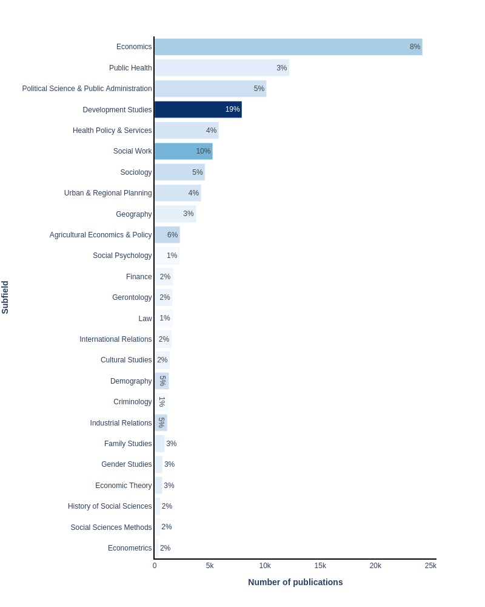

## Journals

In this section, we show how the publication set, captured by the query above, relates to scholarly journals. Journals are sorted in terms of their relevance using term frequency-inverse document frequency (TF-IDF). The horizontal bars are proportional to the number of publications contributed by the journal to the current publication set. The number alongside the horizontal bar is the proportion of the journal contributing to this publication set.

The articles on this topic are published most frequently in the following journals: *World Development* (1,272 publications), *Sustainability (Switzerland)* (1,131), and *Social Science and Medicine* (1,118).

Note, larger journals may not appear in the table below, as their SDG contribution may be relatively small compared to the size of the journal.

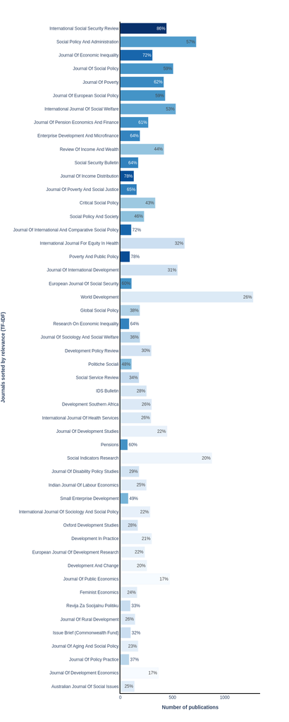

Figure 2. Top 50 journals, in terms of relevance (TF-IDF), for this publication set.

## Keywords

Elsevier’s [Scopus](https://www.scopus.com/search/form.uri?display=basic#basic) database of scientific literature, was used for the table below. The document types included in the data sets are journal articles, reviews, short surveys and conference papers, covering the period 1996–2022. We refer to these documents collectively as “publications” or “papers”.

In order to help better illustrate the content of this set of publications, indicators associated with the keywords most specific to this set (according to a TF-IDF score) are presented below.

|  | Term | # of papers with this term in the publication set | # of papers with this term in all of Scopus | Relevance (TF-IDF) | Percentage of Scopus |
| --- | --- | --- | --- | --- | --- |
| 1 | pro-poor | 2047 | 2557 | 18.496 | 80 |
| 2 | social care services | 1072 | 1337 | 18.4256 | 80 |
| 3 | welfare reform | 2616 | 3460 | 18.3727 | 76 |
| 4 | microfinance institution | 1434 | 1925 | 18.3453 | 74 |
| 5 | poverty rates | 1404 | 1901 | 18.3274 | 74 |
| 6 | poverty rate | 2356 | 3216 | 18.3225 | 73 |
| 7 | microfinance institutions | 1272 | 1720 | 18.3163 | 74 |
| 8 | energy poverty | 1216 | 1638 | 18.3157 | 74 |
| 9 | poverty measure | 1121 | 1543 | 18.2623 | 73 |
| 10 | health and social care services | 626 | 780 | 18.2461 | 80 |

[output cut: 990 more lines]